# Data Transformation Practice

Published

July 20, 2026

Titanic 데이터셋을 이용해 수치형/범주형 데이터 변환과 `agg`의 동작 원리를 연습합니다.

**구성** 1. 수치형 데이터 변환 — 정규화, 표준화, 거듭제곱/Box-Cox 변환 2. 범주형 데이터 변환 — 가변수화(One-Hot), 레이블 인코딩 3. `agg` 심화 — 문자열이 함수로 해석되는 방식

각 문제의 코드 셀에 있는 `# TODO` 부분을 직접 채워보고, 맨 아래의 **해답** 섹션과 비교해보세요.

## 0. 준비

필요한 라이브러리를 불러오고 데이터를 로드합니다.

| Data | Description | Dictionary |
| --- | --- | --- |
| PassengerId | Passenger Id, Index |  |
| Survived | Survival | 0 = No, 1 = Yes |
| Pclass | Ticket class | 1 = 1st, 2 = 2nd, 3 = 3rd |
| Sex | Sex |  |
| Age | Age in years |  |
| SibSp | # of siblings / spouses aboard |  |
| Parch | # of parents / children aboard |  |
| Fare | Passenger fare |  |
| Embarked | Port of Embarkation | C, Q, S |

```python
import pandas as pd
import numpy as np
import seaborn as sns
import matplotlib.pyplot as plt

for i in [pd, np, sns]:
    print(i.__name__, i.__version__)
```

```
pandas 3.0.1
numpy 2.4.3
seaborn 0.13.2
```

```python
# 데이터 로드 - 환경에 맞게 경로를 조정하세요.
df_titanic = pd.read_csv('data/titanic.csv', index_col='PassengerId')
df_titanic.head()
```

| PassengerId | Survived | Pclass | Name | Sex | Age | SibSp | Parch | Ticket | Fare | Cabin | Embarked |
| --- | --- | --- | --- | --- | --- | --- | --- | --- | --- | --- | --- |
| 1 | 0 | 3 | Braund, Mr. Owen Harris | male | 22.0 | 1 | 0 | A/5 21171 | 7.2500 | NaN | S |
| 2 | 1 | 1 | Cumings, Mrs. John Bradley (Florence Briggs Th... | female | 38.0 | 1 | 0 | PC 17599 | 71.2833 | C85 | C |
| 3 | 1 | 3 | Heikkinen, Miss. Laina | female | 26.0 | 0 | 0 | STON/O2. 3101282 | 7.9250 | NaN | S |
| 4 | 1 | 1 | Futrelle, Mrs. Jacques Heath (Lily May Peel) | female | 35.0 | 1 | 0 | 113803 | 53.1000 | C123 | S |
| 5 | 0 | 3 | Allen, Mr. William Henry | male | 35.0 | 0 | 0 | 373450 | 8.0500 | NaN | S |

## 1. 수치형 데이터 변환

### 문제 1. Min-Max 정규화

`sklearn.preprocessing.MinMaxScaler`를 이용해 `Age`, `Fare`를 최소값 0, 최대값 1이 되도록 변환하세요.

- 변환값은 `Age_n`, `Fare_n` 컬럼으로 저장합니다.
- 변환 결과가 실제로 [0, 1] 범위인지 `agg(['min', 'max'])`로 검증합니다.

> $X_{new} = \dfrac{X - \min(X)}{\max(X) - \min(X)}$

**주의**: `scaler.transform()`의 결과는 numpy array이므로, DataFrame에 복수 컬럼으로 추가할 때는 `pd.DataFrame(..., index=df_titanic.index)`로 감싸 인덱스를 맞춰야 합니다.

```python
from sklearn.preprocessing import MinMaxScaler

mm_cols = ['Age', 'Fare']
mm_cols_n = [c + '_n' for c in mm_cols]

# TODO: MinMaxScaler를 생성하고 fit 후 transform 결과를 mm_cols_n 컬럼으로 추가하세요.


# TODO: agg를 이용해 min, max를 확인하세요.
```

### 문제 2. feature_range 지정

이번에는 최소값 −1, 최대값 1이 되도록 변환하고, `fit`과 `transform`을 한 번에 수행하는 `fit_transform`을 사용하세요. 결과는 동일하게 `Age_n`, `Fare_n`에 덮어씁니다. `agg(['min', 'max'])`로 범위를 검증하세요.

```python
# TODO: MinMaxScaler((-1, 1))을 이용해 변환하고 검증하세요.
```

### 문제 3. 공식 직접 구현으로 검증

`MinMaxScaler`를 쓰지 않고 정규화 공식을 pandas 연산만으로 직접 구현해 `Fare_n_manual` 컬럼을 만들어보세요 (범위 [0, 1] 기준).

그리고 문제 1 방식의 `MinMaxScaler` 결과와 일치하는지 `np.allclose`로 확인하세요.

> 수학적으로 같은 식이라도 부동소수점 연산 순서에 따라 미세한 차이가 날 수 있어 `==`가 아닌 `np.allclose`로 비교하는 것이 안전합니다.

```python
# TODO: 공식을 직접 구현해 Fare_n_manual을 만드세요.


# TODO: MinMaxScaler 결과(범위 [0,1])와 np.allclose로 비교하세요.
```

### 문제 4. 표준화 (StandardScaler)

`StandardScaler`로 `Age`, `Fare`를 표준화해 `Age_s`, `Fare_s`로 저장하세요.

> $X_{std} = \dfrac{X - \mu}{\sigma}$

검증: 평균이 0, 표준편차가 1인지 확인하되, `StandardScaler`는 **편향(biased) 표준편차** (`ddof=0`)를 사용한다는 점에 주의하세요. `df.std()`의 기본값은 `ddof=1`이므로 그대로 쓰면 1이 아닌 값이 나옵니다.

`mean`과 `std(ddof=0)`를 하나의 결과 테이블로 정리해 출력하세요.

```python
from sklearn.preprocessing import StandardScaler

std_cols = ['Age', 'Fare']
std_cols_s = [c + '_s' for c in std_cols]

# TODO: 표준화 후 mean과 std(ddof=0)를 확인하세요.
```

### 문제 5. 편향 vs 불편향 표준편차

`scipy.stats.zscore`에 `ddof=1`을 지정해 `Fare`를 **불편향(unbiased) 표준편차** 기준으로 표준화하고 `Fare_s2`에 저장하세요.

그리고 다음을 확인하세요.

1. `Fare_s`(StandardScaler, ddof=0)와 `Fare_s2`(zscore, ddof=1)의 값 차이
2. 두 결과의 비율 `Fare_s / Fare_s2`가 상수인지 — 그 상수가 $\sqrt{n/(n-1)}$과 일치하는지

**생각해보기**: 표본 크기 $n$이 커질수록 두 방식의 차이는 어떻게 될까요?

```python
from scipy.stats import zscore

# TODO: ddof=1로 표준화해 Fare_s2를 만드세요.


# TODO: Fare_s / Fare_s2의 비율을 확인하고 sqrt(n/(n-1))과 비교하세요.
```

### 문제 6. 거듭제곱 변환 (Power Transformation)

λ = [-2, -1, -0.5, 0, 0.5, 1, 1.5, 2]에 대해 거듭제곱 변환된 `Fare`의 분포를 2×4 히스토그램으로 출력하세요.

| $\lambda$ | 변환 |
| --- | --- |
| $\lambda \ne 0$ | $X^{\lambda}$ |
| $\lambda = 0$ | $\log(X)$ |

**주의**: `Fare`에는 0이 존재하므로 λ=0(log 변환)일 때는 $\log(X+1)$을 사용하세요. 또한 λ<0(역수 계열)일 때 0은 무한대가 되므로, 그래프 해석 시 이 점을 염두에 두세요.

```python
# TODO: 2x4 subplot에 lambda별 히스토그램을 그리세요.
lams = [-2, -1, -0.5, 0, 0.5, 1, 1.5, 2]
```

### 문제 7. Box-Cox 변환

`PowerTransformer(method='box-cox')`로 결측을 제외한 `Age`를 변환하고,

1. 자동으로 추정된 λ (`pt.lambdas_`)를 확인하세요.
2. 변환 전/후의 왜도(skewness)를 `skew()`로 비교하세요.
3. 변환 전/후 히스토그램을 나란히 그려 분포가 대칭에 가까워졌는지 확인하세요.

> Box-Cox는 $\lambda \ne 0$일 때 $\frac{X^{\lambda}-1}{\lambda}$, $\lambda=0$일 때 $\log X$를 사용하며, 데이터를 정규분포에 가깝게 만드는 λ를 우도 기반으로 추정합니다. 입력값이 양수여야 한다는 제약이 있습니다.

```python
from sklearn.preprocessing import PowerTransformer

s_age = df_titanic.loc[df_titanic['Age'].notna(), 'Age']

# TODO: box-cox 변환 후 lambdas_, skew, 히스토그램을 확인하세요.
```

## 2. 범주형 데이터 변환

### 문제 8. 가변수화 — pd.get_dummies

1. `Embarked`의 결측치를 최빈값으로 대체하세요.
2. `pd.get_dummies`로 `Pclass`와 `Embarked`를 가변수화한 `df_titanic_gd`를 만드세요.
3. 생성된 가변수 컬럼명들을 확인하세요.

```python
# TODO: 결측 대체 후 get_dummies로 가변수화하세요.
```

### 문제 9. 가변수화 — OneHotEncoder

`sklearn.preprocessing.OneHotEncoder`로 문제 8과 동일한 결과의 `df_titanic_ohe`를 만드세요.

- `sparse_output=False`로 설정해 dense array를 얻으세요.
- `get_feature_names_out()`으로 컬럼명을 만들어 DataFrame으로 결합하세요.
- 원본에서 `Pclass`, `Embarked`를 제거한 뒤 `pd.concat`으로 붙이세요.
- 마지막으로 `df_titanic_gd`와 값이 동일한지 비교하세요. (get_dummies는 bool, OneHotEncoder는 float을 반환하므로 dtype을 맞춘 뒤 비교하세요.)

**생각해보기**: 실무 파이프라인에서 `get_dummies` 대신 `OneHotEncoder`를 선호하는 이유는 무엇일까요? (힌트: 학습 데이터에 없던 범주가 테스트 데이터에 등장하는 경우)

```python
from sklearn.preprocessing import OneHotEncoder

ohe_cols = ['Pclass', 'Embarked']

# TODO: OneHotEncoder로 가변수화하고 get_dummies 결과와 비교하세요.
```

### 문제 10. 레이블 인코딩

`LabelEncoder`로 `Embarked`를 인코딩해 `Embarked_l` 컬럼을 만드세요.

1. `le.classes_`로 범주 → 정수 매핑을 확인하세요.
2. `inverse_transform`으로 정수를 다시 원래 범주로 되돌릴 수 있음을 확인하세요.

**생각해보기**: `LabelEncoder`는 다른 transformer들과 달리 2차원이 아닌 1차원 입력을 받습니다. 이 설계에서 `LabelEncoder`의 본래 용도(입력 변수용인지, 대상값용인지)를 추론해보세요. 또한 순서가 없는 명목형 변수를 레이블 인코딩해 선형 모델에 넣으면 어떤 문제가 생길까요?

```python
from sklearn.preprocessing import LabelEncoder

# TODO: LabelEncoder로 인코딩하고 classes_, inverse_transform을 확인하세요.
```

## 3. `agg` 심화 — 문자열은 어떻게 함수가 되는가

`df.agg(['min', 'max'])`의 `'min'`, `'max'`는 Python 예약어가 아니라, pandas가 **문자열 → 메서드 매핑 규칙**에 따라 해석하는 이름입니다.

- 자주 쓰이는 통계량(`min`, `max`, `sum`, `mean`, `std`, …)은 최적화된 내부 구현으로 매핑됩니다.
- 그 외에는 `getattr(객체, 문자열)`처럼 해당 이름의 메서드를 찾아 호출합니다.

이 원리를 직접 확인해봅니다.

### 문제 11. 문자열 vs 함수 객체 vs 사용자 정의 함수

`Age_n`, `Fare_n`에 대해 다음 세 가지를 **하나의 `agg` 호출**에 섞어 적용하세요.

1. 문자열: `'min'`, `'max'`
2. NumPy 함수 객체: `np.median`
3. 사용자 정의 함수: 최대값과 최소값의 차이를 반환하는 `value_range` 함수

결과 테이블의 행 인덱스에 각 집계의 이름이 어떻게 표시되는지도 관찰하세요.

```python
def value_range(x):
    # TODO: 최대값 - 최소값을 반환하도록 구현하세요.
    pass

# TODO: 문자열, np.median, value_range를 섞어 agg를 호출하세요.
```

### 문제 12. 문자열 해석 원리 확인

1. `df_titanic[['Age_n', 'Fare_n']].agg('median')`과 `getattr(df_titanic[['Age_n', 'Fare_n']], 'median')()`의 결과가 같은지 확인하세요.
2. 존재하지 않는 이름 `'not_a_real_method'`를 `agg`에 넘겨보고, `try/except`로 어떤 예외가 발생하는지 출력하세요.

이를 통해 문자열이 “예약어”가 아니라 **객체가 실제로 가진 메서드 이름**이면 무엇이든 동작한다는 것을 확인할 수 있습니다.

```python
# TODO: agg('median')과 getattr 방식의 결과를 비교하세요.


# TODO: 존재하지 않는 이름을 넘겨 예외를 확인하세요.
```

### 문제 13. 컬럼별로 다른 집계 적용 (dict 형태)

dict를 이용해 컬럼마다 다른 집계를 적용하세요.

- `Age`: `'min'`, `'max'`, `'mean'`
- `Fare`: `'median'`, `'std'`
- `Survived`: `'mean'` (생존율로 해석 가능)

결과에서 특정 컬럼에 적용되지 않은 집계 자리가 어떻게 표시되는지(NaN) 관찰하세요.

```python
# TODO: dict 형태의 agg를 호출하세요.
```

# 해답

### 해답 1

```python
from sklearn.preprocessing import MinMaxScaler

mm_cols = ['Age', 'Fare']
mm_cols_n = [c + '_n' for c in mm_cols]

mm_scaler = MinMaxScaler()
mm_scaler.fit(df_titanic[mm_cols])

# transform 결과는 numpy array이므로 DataFrame으로 감싸 인덱스를 맞춥니다.
df_titanic[mm_cols_n] = pd.DataFrame(
    mm_scaler.transform(df_titanic[mm_cols]), index=df_titanic.index
)
df_titanic[mm_cols_n].agg(['min', 'max'])
```

|  | Age_n | Fare_n |
| --- | --- | --- |
| min | 0.0 | 0.0 |
| max | 1.0 | 1.0 |

### 해답 2

```python
mm_scaler = MinMaxScaler((-1, 1))
df_titanic[mm_cols_n] = pd.DataFrame(
    mm_scaler.fit_transform(df_titanic[mm_cols]), index=df_titanic.index
)
df_titanic[mm_cols_n].agg(['min', 'max'])
```

|  | Age_n | Fare_n |
| --- | --- | --- |
| min | -1.0 | -1.0 |
| max | 1.0 | 1.0 |

### 해답 3

```python
s = df_titanic['Fare']
df_titanic['Fare_n_manual'] = (s - s.min()) / (s.max() - s.min())

# 비교 기준을 [0, 1] 범위로 다시 맞춥니다.
mm_scaler01 = MinMaxScaler()
fare_n_sklearn = mm_scaler01.fit_transform(df_titanic[['Fare']])[:, 0]

print(np.allclose(df_titanic['Fare_n_manual'].values, fare_n_sklearn))
```

```
True
```

### 해답 4

```python
from sklearn.preprocessing import StandardScaler

std_cols = ['Age', 'Fare']
std_cols_s = [c + '_s' for c in std_cols]

std_scaler = StandardScaler()
df_titanic[std_cols_s] = pd.DataFrame(
    std_scaler.fit_transform(df_titanic[std_cols]), index=df_titanic.index
)

pd.concat([
    df_titanic[std_cols_s].mean().rename('mean'),
    df_titanic[std_cols_s].std(ddof=0).rename('std(ddof=0)')
], axis=1)
```

|  | mean | std(ddof=0) |
| --- | --- | --- |
| Age_s | 2.388379e-16 | 1.0 |
| Fare_s | 3.987333e-18 | 1.0 |

### 해답 5

```python
from scipy.stats import zscore

df_titanic['Fare_s2'] = zscore(df_titanic['Fare'], ddof=1)
print(df_titanic['Fare_s2'].agg(['mean', 'std']))

# 두 표준화 결과의 비율은 상수입니다.
ratio = (df_titanic['Fare_s'] / df_titanic['Fare_s2']).dropna()
n = df_titanic['Fare'].notna().sum()
print('ratio (unique):', ratio.round(10).unique())
print('sqrt(n/(n-1)) :', np.sqrt(n / (n - 1)))
# n이 커질수록 sqrt(n/(n-1)) -> 1 이므로 두 방식의 차이는 사라집니다.
```

```
mean   -1.196200e-17
std     1.000000e+00
Name: Fare_s2, dtype: float64
ratio (unique): [1.00056164]
sqrt(n/(n-1)) : 1.0005616400330457
```

### 해답 6

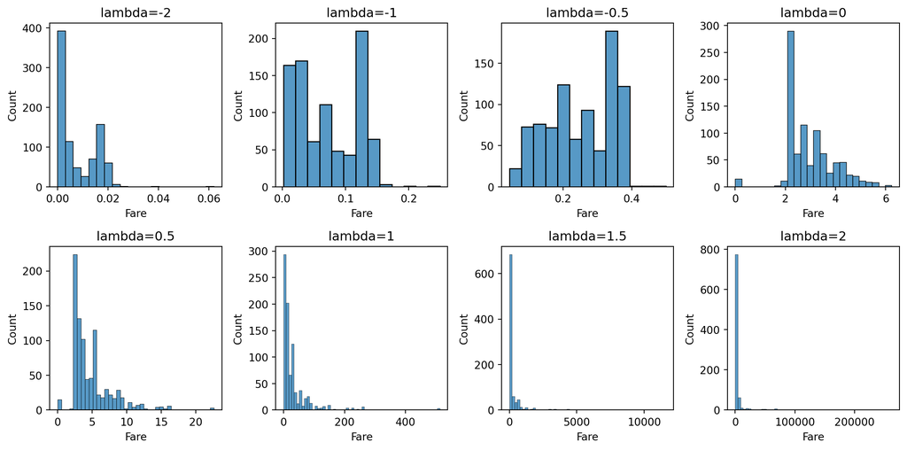

```python
fig, axes = plt.subplots(2, 4, figsize=(12, 6))
lams = [-2, -1, -0.5, 0, 0.5, 1, 1.5, 2]
for lam, ax in zip(lams, axes.ravel()):
    if lam != 0:
        sns.histplot(df_titanic['Fare'] ** lam, ax=ax)
    else:
        # Fare에 0이 있으므로 log(X + 1)을 사용합니다.
        sns.histplot(np.log(df_titanic['Fare'] + 1), ax=ax)
    ax.set_title('lambda={}'.format(lam))
plt.tight_layout()
plt.show()
```

### 해답 7

```
estimated lambda: 0.762789049635355
skew before: 0.38910778230082693
skew after : -0.04907434955378815
```

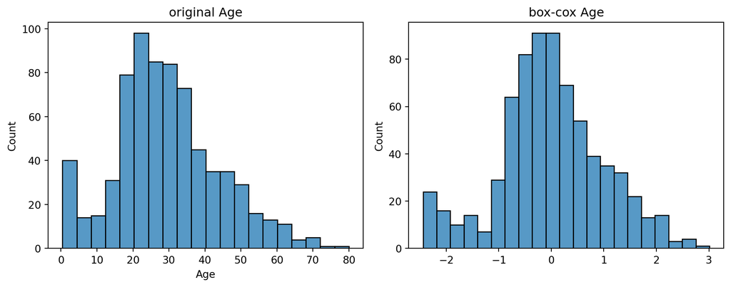

```python
from sklearn.preprocessing import PowerTransformer

s_age = df_titanic.loc[df_titanic['Age'].notna(), 'Age']

pt = PowerTransformer(method='box-cox')
age_bc = pt.fit_transform(s_age.to_frame())[:, 0]

print('estimated lambda:', pt.lambdas_[0])
print('skew before:', s_age.skew())
print('skew after :', pd.Series(age_bc).skew())

fig, axes = plt.subplots(1, 2, figsize=(10, 4))
sns.histplot(s_age, ax=axes[0]); axes[0].set_title('original Age')
sns.histplot(age_bc, ax=axes[1]); axes[1].set_title('box-cox Age')
plt.tight_layout()
plt.show()
```

### 해답 8

```python
df_titanic['Embarked'] = df_titanic['Embarked'].fillna(
    df_titanic['Embarked'].mode().iloc[0]
)

df_titanic_gd = pd.get_dummies(df_titanic, columns=['Pclass', 'Embarked'])
print([c for c in df_titanic_gd.columns if c.startswith(('Pclass_', 'Embarked_'))])
df_titanic_gd.head()
```

```
['Pclass_1', 'Pclass_2', 'Pclass_3', 'Embarked_C', 'Embarked_Q', 'Embarked_S']
```

| PassengerId | Survived | Name | Sex | Age | SibSp | Parch | Ticket | Fare | Cabin | Age_n | ... | Fare_n_manual | Age_s | Fare_s | Fare_s2 | Pclass_1 | Pclass_2 | Pclass_3 | Embarked_C | Embarked_Q | Embarked_S |
| --- | --- | --- | --- | --- | --- | --- | --- | --- | --- | --- | --- | --- | --- | --- | --- | --- | --- | --- | --- | --- | --- |
| 1 | 0 | Braund, Mr. Owen Harris | male | 22.0 | 1 | 0 | A/5 21171 | 7.2500 | NaN | -0.457653 | ... | 0.014151 | -0.530377 | -0.502445 | -0.502163 | False | False | True | False | False | True |
| 2 | 1 | Cumings, Mrs. John Bradley (Florence Briggs Th... | female | 38.0 | 1 | 0 | PC 17599 | 71.2833 | C85 | -0.055542 | ... | 0.139136 | 0.571831 | 0.786845 | 0.786404 | True | False | False | True | False | False |
| 3 | 1 | Heikkinen, Miss. Laina | female | 26.0 | 0 | 0 | STON/O2. 3101282 | 7.9250 | NaN | -0.357125 | ... | 0.015469 | -0.254825 | -0.488854 | -0.488580 | False | False | True | False | False | True |
| 4 | 1 | Futrelle, Mrs. Jacques Heath (Lily May Peel) | female | 35.0 | 1 | 0 | 113803 | 53.1000 | C123 | -0.130937 | ... | 0.103644 | 0.365167 | 0.420730 | 0.420494 | True | False | False | False | False | True |
| 5 | 0 | Allen, Mr. William Henry | male | 35.0 | 0 | 0 | 373450 | 8.0500 | NaN | -0.130937 | ... | 0.015713 | 0.365167 | -0.486337 | -0.486064 | False | False | True | False | False | True |

5 rows × 21 columns

### 해답 9

```python
from sklearn.preprocessing import OneHotEncoder

ohe = OneHotEncoder(sparse_output=False)
ohe_cols = ['Pclass', 'Embarked']
ohe.fit(df_titanic[ohe_cols])

df_titanic_ohe = pd.concat([
    df_titanic.drop(columns=ohe_cols),
    pd.DataFrame(ohe.transform(df_titanic[ohe_cols]),
                 index=df_titanic.index,
                 columns=ohe.get_feature_names_out(ohe_cols))
], axis=1)

# get_dummies는 bool, OneHotEncoder는 float을 반환하므로 dtype을 맞춰 비교합니다.
dummy_cols = ohe.get_feature_names_out(ohe_cols)
print(
    (df_titanic_gd[dummy_cols].astype(float) != df_titanic_ohe[dummy_cols]).sum()
)
# OneHotEncoder는 fit 시점의 범주를 기억하므로,
# 학습/테스트 데이터 간 범주 구성이 달라도 일관된 컬럼을 만들 수 있습니다.
# handle_unknown='ignore' 옵션으로 미지의 범주도 처리할 수 있습니다.
```

```
Pclass_1      0
Pclass_2      0
Pclass_3      0
Embarked_C    0
Embarked_Q    0
Embarked_S    0
dtype: int64
```

### 해답 10

```python
from sklearn.preprocessing import LabelEncoder

le = LabelEncoder()
df_titanic['Embarked_l'] = le.fit_transform(df_titanic['Embarked'])

print('classes_:', le.classes_)  # index가 곧 인코딩된 정수입니다.
print(le.inverse_transform([0, 1, 2]))
df_titanic[['Embarked', 'Embarked_l']].head()

# LabelEncoder는 1차원 입력만 받도록 설계되어 있어, 본래 대상값(y) 인코딩용입니다.
# 명목형 변수를 정수로 치환해 선형 모델에 넣으면
# 존재하지 않는 순서/간격 정보가 주입되는 문제가 생깁니다.
```

```
classes_: ['C' 'Q' 'S']
['C' 'Q' 'S']
```

| PassengerId | Embarked | Embarked_l |
| --- | --- | --- |
| 1 | S | 2 |
| 2 | C | 0 |
| 3 | S | 2 |
| 4 | S | 2 |
| 5 | S | 2 |

### 해답 11

```python
def value_range(x):
    return x.max() - x.min()

df_titanic[['Age_n', 'Fare_n']].agg(['min', 'max', np.median, value_range])
# 문자열은 그대로, 함수 객체는 __name__ 속성이 행 인덱스 이름으로 사용됩니다.
```

|  | Age_n | Fare_n |
| --- | --- | --- |
| min | -1.0 | -1.000000 |
| max | 1.0 | 1.000000 |
| median | NaN | -0.943575 |
| value_range | 2.0 | 2.000000 |

### 해답 12

```python
r1 = df_titanic[['Age_n', 'Fare_n']].agg('median')
r2 = getattr(df_titanic[['Age_n', 'Fare_n']], 'median')()
print(r1.equals(r2))  # True - 문자열은 결국 같은 이름의 메서드 호출로 해석됩니다.

try:
    df_titanic[['Age_n', 'Fare_n']].agg('not_a_real_method')
except Exception as e:
    print(type(e).__name__, ':', e)
```

```
True
AttributeError : 'not_a_real_method' is not a valid function for 'DataFrame' object
```

### 해답 13

```python
df_titanic.agg({
    'Age': ['min', 'max', 'mean'],
    'Fare': ['median', 'std'],
    'Survived': ['mean'],
})
# 컬럼에 적용되지 않은 집계 자리는 NaN으로 채워집니다.
```

|  | Age | Fare | Survived |
| --- | --- | --- | --- |
| min | 0.420000 | NaN | NaN |
| max | 80.000000 | NaN | NaN |
| mean | 29.699118 | NaN | 0.383838 |
| median | NaN | 14.454200 | NaN |
| std | NaN | 49.693429 | NaN |